# final project

Sandas Wijethunga

2025-03-09

Data Analysis

```r
library(ggplot2)
library(dplyr)
library(caret)
library(corrplot)
library(lmtest)
library(stats)
library(car)
library(readxl)
file_path <- "C:/Users/ASUS/Downloads/final project.xlsx"
df <- read_excel(file_path)
View(df)
head(df)
```

```
## # A tibble: 6 × 12
##     Age Gender Degree_program        Favorite_music_genre  `No_of_ music_genres`
##   <dbl> <chr>  <chr>                 <chr>                                 <dbl>
## 1    20 Female Data science          Hip-hop/Rap, Classic…                     2
## 2    22 Female Interior architecture Pop, Jazz, Classical                      3
## 3    25 Female Fashion designing     Pop, Hip-hop/Rap, Cl…                     2
## 4    23 Female Fashion designing     Classical, Electroni…                     3
## 5    21 Female Interior architecture Pop, Classical, Elec…                     4
## 6    24 Female Fashion designing     Pop, Other                                3
## # ℹ 7 more variables: Daily_listening_time <dbl>, Primary_Music_Platform <chr>,
## #   Live_vs_streaming_prefrences <chr>, Primary_listening_activity <chr>,
## #   Music_discovey_preferences <chr>, Music_motivation <chr>,
## #   Music_and_mental_health <chr>
```

```r
summary(df)
```

```
##       Age           Gender          Degree_program     Favorite_music_genre
##  Min.   :18.00   Length:207         Length:207         Length:207
##  1st Qu.:21.00   Class :character   Class :character   Class :character
##  Median :22.00   Mode  :character   Mode  :character   Mode  :character
##  Mean   :21.88
##  3rd Qu.:23.00
##  Max.   :27.00
##  No_of_ music_genres Daily_listening_time Primary_Music_Platform
##  Min.   :1.000       Min.   : 0.0         Length:207
##  1st Qu.:2.000       1st Qu.: 2.0         Class :character
##  Median :3.000       Median : 3.0         Mode  :character
##  Mean   :3.517       Mean   : 3.6
##  3rd Qu.:4.500       3rd Qu.: 5.0
##  Max.   :8.000       Max.   :15.0
##  Live_vs_streaming_prefrences Primary_listening_activity
##  Length:207                   Length:207
##  Class :character             Class :character
##  Mode  :character             Mode  :character
##
##
##
##  Music_discovey_preferences Music_motivation   Music_and_mental_health
##  Length:207                 Length:207         Length:207
##  Class :character           Class :character   Class :character
##  Mode  :character           Mode  :character   Mode  :character
##
##
##
```

Check NA values

```r
# Count the number of NAs in each column
na_count <- sapply(df, function(x) sum(is.na(x)))

# Print the result
print("Number of NAs in each column:")
```

```
## [1] "Number of NAs in each column:"
```

```r
print(na_count)
```

```
##                          Age                       Gender
##                            0                            0
##               Degree_program         Favorite_music_genre
##                            0                            0
##          No_of_ music_genres         Daily_listening_time
##                            0                            0
##       Primary_Music_Platform Live_vs_streaming_prefrences
##                            0                            0
##   Primary_listening_activity   Music_discovey_preferences
##                            0                            0
##             Music_motivation      Music_and_mental_health
##                            0                            0
```

Checking outliers and renaming data set after removing outliers

```r
# Identify numeric columns
numeric_cols <- sapply(df, is.numeric)
# Function to detect outliers based on IQR method
detect_outliers <- function(column) {
  Q1 <- quantile(column, 0.25, na.rm = TRUE)
  Q3 <- quantile(column, 0.75, na.rm = TRUE)
  IQR_value <- Q3 - Q1
  lower_bound <- Q1 - 1.5 * IQR_value
  upper_bound <- Q3 + 1.5 * IQR_value
  outliers <- column[column < lower_bound | column > upper_bound]
  return(outliers)
}
outliers_list <- lapply(df[, numeric_cols, drop = FALSE], detect_outliers)
print("Outliers in each numeric column:")
```

```
## [1] "Outliers in each numeric column:"
```

```r
print(outliers_list)
```

```
## $Age
## [1] 27 27 27
##
## $`No_of_ music_genres`
## numeric(0)
##
## $Daily_listening_time
## [1] 12 10 12 15 12 12 10 10 12
```

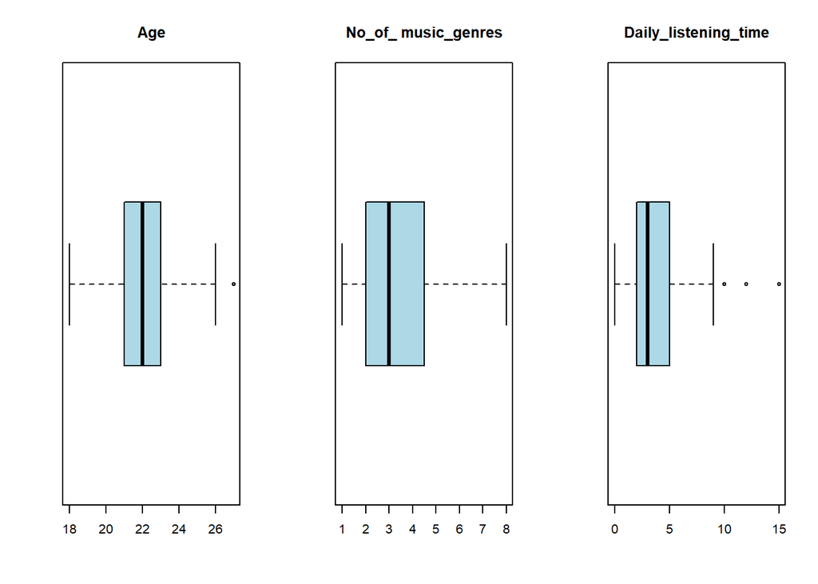

```r
# Boxplots for visualization
par(mfrow=c(ceiling(sum(numeric_cols)/3),3))
for (col in names(df)[numeric_cols]) {
  boxplot(df[[col]], main=col, col="lightblue", horizontal=TRUE)
}
```

```r
par(mfrow=c(1,1))
```

```r
# Identify numeric columns
numeric_cols <- sapply(df, is.numeric)

# Function to detect outliers based on IQR method for each column
detect_outliers <- function(column) {
  Q1 <- quantile(column, 0.25, na.rm = TRUE)
  Q3 <- quantile(column, 0.75, na.rm = TRUE)
  IQR_value <- Q3 - Q1
  lower_bound <- Q1 - 1.5 * IQR_value
  upper_bound <- Q3 + 1.5 * IQR_value

  # Identify rows where the values are outliers
  outliers <- which(column < lower_bound | column > upper_bound)
  return(outliers)
}

# Apply outlier detection to each numeric column
outliers_list <- lapply(df[, numeric_cols, drop = FALSE], detect_outliers)

# Combine all outlier indices from all columns (get unique row indices)
outlier_indices <- unique(unlist(outliers_list))

# Remove rows containing any outliers
df_cleaned <- df[-outlier_indices, ]

# Print cleaned dataset dimensions
print("Cleaned dataset dimensions:")
```

```
## [1] "Cleaned dataset dimensions:"
```

```r
print(dim(df_cleaned))
```

```
## [1] 195  12
```

```r
print(paste("Cleaned dataset rows:", nrow(df_cleaned)))
```

```
## [1] "Cleaned dataset rows: 195"
```

```r
View(df_cleaned)
```

Visulaizations

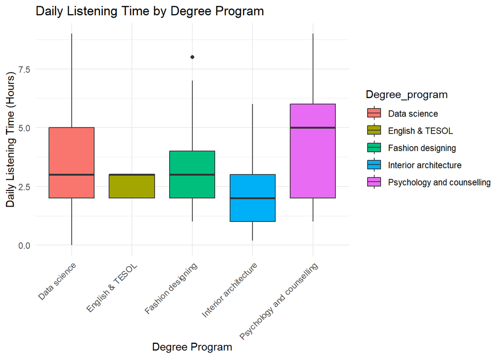

```r
ggplot(df_cleaned, aes(x = Degree_program, y = Daily_listening_time, fill = Degree_program)) +
  geom_boxplot() +
  labs(title = "Daily Listening Time by Degree Program",
       x = "Degree Program",
       y = "Daily Listening Time (Hours)") +
  theme_minimal() +
  theme(axis.text.x = element_text(angle = 45, hjust = 1))
```

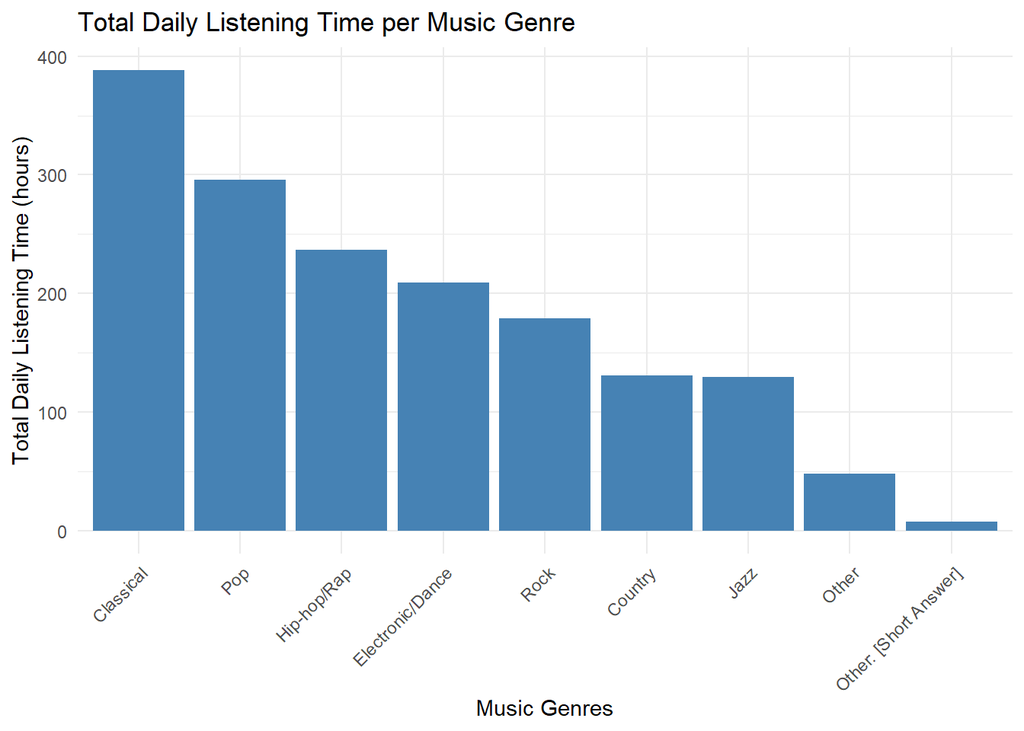

```r
library(tidyr)
df_exploded <- df_cleaned %>%
  separate_rows(Favorite_music_genre, sep = ", ")


genre_listening_time <- df_exploded %>%
  group_by(Favorite_music_genre) %>%
  summarise(Total_Listening_Time = sum(Daily_listening_time, na.rm = TRUE)) %>%
  arrange(desc(Total_Listening_Time))


ggplot(genre_listening_time, aes(x = reorder(Favorite_music_genre, -Total_Listening_Time), y = Total_Listening_Time)) +
  geom_bar(stat = "identity", fill = "steelblue") +
  labs(title = "Total Daily Listening Time per Music Genre", x = "Music Genres", y = "Total Daily Listening Time (hours)") +
  theme_minimal() +
  theme(axis.text.x = element_text(angle = 45, hjust = 1))
```

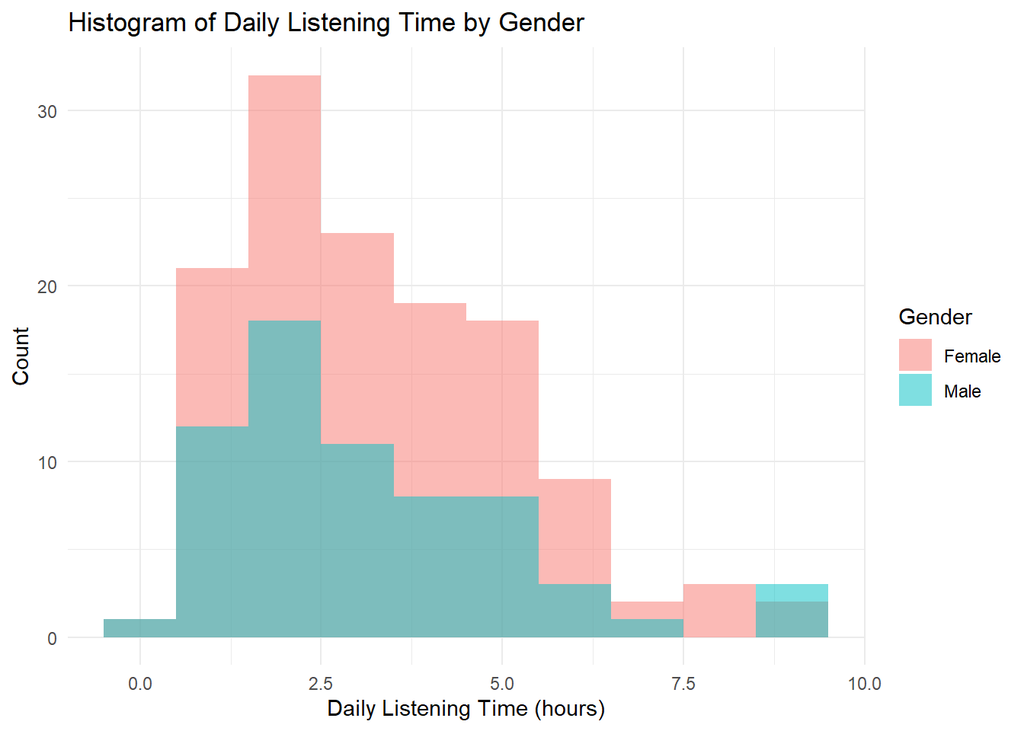

```r
ggplot(df_cleaned, aes(x = Daily_listening_time, fill = Gender)) +
  geom_histogram(binwidth = 1, alpha = 0.5, position = "identity") +
  labs(title = "Histogram of Daily Listening Time by Gender",
       x = "Daily Listening Time (hours)",
       y = "Count") +
  theme_minimal()
```

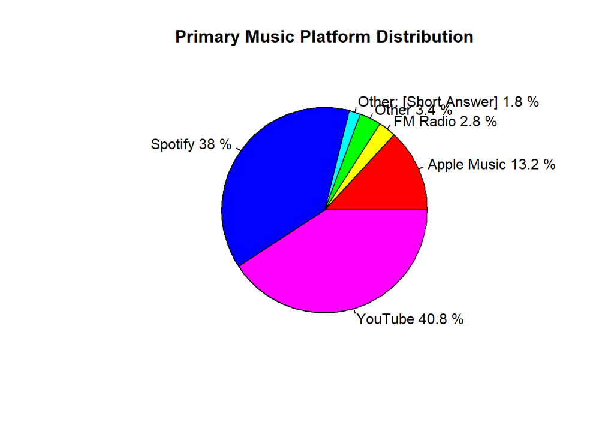

```r
# Extract the 'Primary_Music_Platform' column and remove NAs
platforms <- na.omit(df_cleaned$Primary_Music_Platform)

# Split multiple platform entries and count occurrences
platform_list <- unlist(strsplit(platforms, ",\\s*"))
platform_counts <- table(platform_list)

# Calculate percentages
percentages <- round(100 * platform_counts / sum(platform_counts), 1)
labels <- paste(names(platform_counts), percentages, "%")

# Plot the pie chart with percentages
pie(platform_counts, labels = labels, main = "Primary Music Platform Distribution", col = rainbow(length(platform_counts)))
```

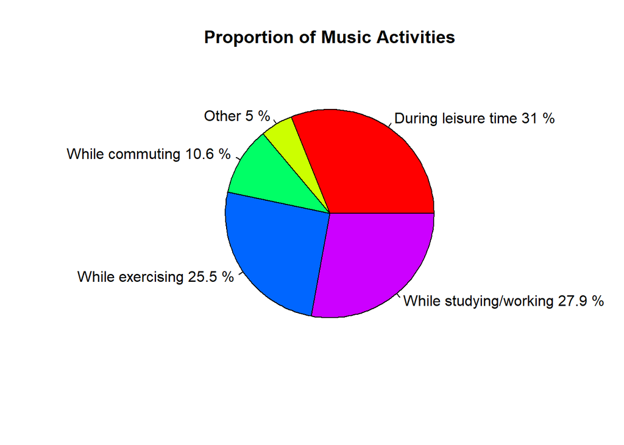

```r
# Pie chart for primary listening activity
activities <- na.omit(df_cleaned$Primary_listening_activity)
activity_list <- unlist(strsplit(activities, ",\\s*"))

activity_counts <- table(activity_list)

percentages <- round(100 * activity_counts / sum(activity_counts), 1)
labels <- paste(names(activity_counts), percentages, "%")
pie(activity_counts, labels = labels, main = "Proportion of Music Activities", col = rainbow(length(activity_counts)))
```

Objectives and Hypothesis

Objective: 1 To determine whether there is a significant difference in daily listening time based on favorite music genre among young adults.

ANOVA

- H0: The population means of daily listening time grouped according to favorite music genres is equal to each other.
- H1: At least one of the population means of the daily listening time is not equal to another.

```r
attach(df_cleaned)
anova= aov(Daily_listening_time ~ Favorite_music_genre,data=df_cleaned)
summary(anova)
```

```
##                       Df Sum Sq Mean Sq F value Pr(>F)
## Favorite_music_genre  75  263.1   3.508   0.898   0.69
## Residuals            119  464.8   3.906
```

Testing Assumptions 1. Homogeneity of Variance

- H0: The population variance of daily listening time grouped according to favorite music genres is equal to each other.
- H1: At least one of the population variances of the daily listening time is not equal to another.

```r
leveneTest(anova)
```

```
## Levene's Test for Homogeneity of Variance (center = median)
##        Df F value Pr(>F)
## group  75  0.9402 0.6097
##       119
```

2. Normality
- HO : the sample residuals are not significantly different than a normal distribution.
- H1 : the sample residuals are significantly different than a normal distribution.

```r
anova.residuals=residuals(anova)
shapiro.test(anova.residuals)
```

```
##
##  Shapiro-Wilk normality test
##
## data:  anova.residuals
## W = 0.96413, p-value = 7.12e-05
```

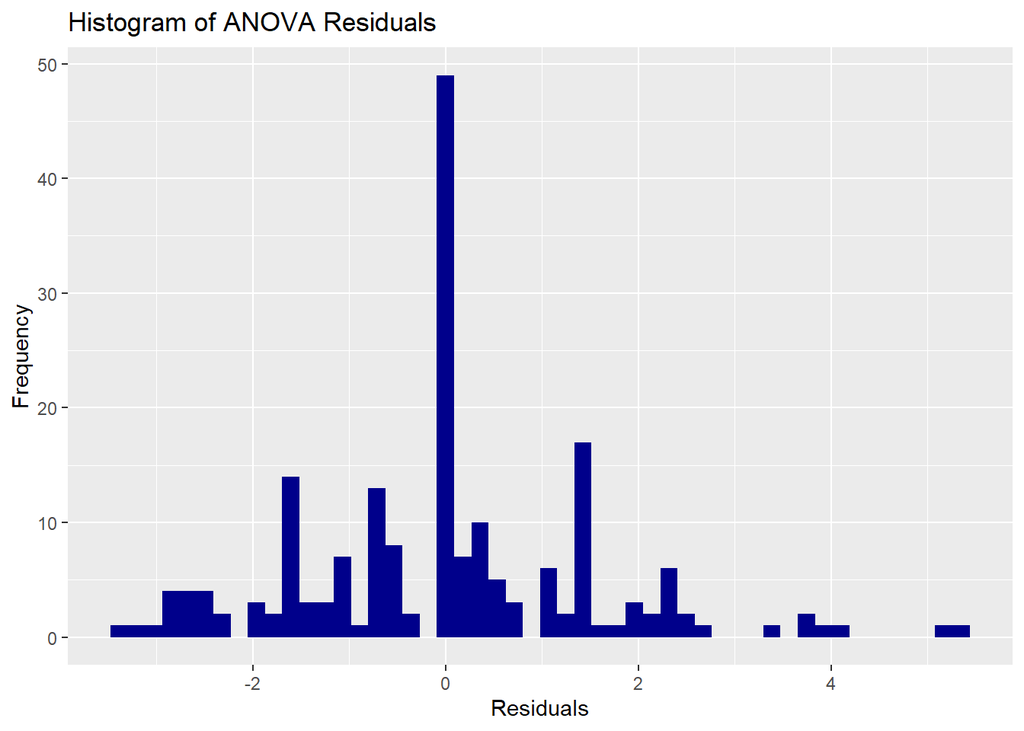

```r
df<-data.frame(anova.residuals)
ggplot(df_cleaned, aes(x = anova.residuals)) +
  geom_histogram(bins=50,fill="blue4") +
  labs(title = "Histogram of ANOVA Residuals", x = "Residuals", y = "Frequency")
```

3. Independence test

- HO : observations are independent in the population.
- H1 : observations are not independent in the population.

```r
dw.data=durbinWatsonTest(anova)
dw.data
```

```
##  lag Autocorrelation D-W Statistic p-value
##    1     -0.03648922      2.059532   0.828
##  Alternative hypothesis: rho != 0
```

- Since one out of the three assumptions of ANOVA is rejected, this suggests that ANOVA is not a suitable model for further analysis.
- The non-parametric alternative to ANOVA which is the Kruskal-Wallis test can be used.

Kruskal Wallis Test

- H0: The population medians of daily listening time grouped according to favorite music genres is equal to each other.
- H1: At least one of the population medians of the daily listening time is not equal to another.

```r
kr.data=kruskal.test(Daily_listening_time ~ Favorite_music_genre)
kr.data
```

```
##
##  Kruskal-Wallis rank sum test
##
## data:  Daily_listening_time by Favorite_music_genre
## Kruskal-Wallis chi-squared = 65.529, df = 75, p-value = 0.7744
```

Objective: 2

To determine whether there is a significant difference in the average time spent listening to music based on demographic factors among listeners.

1.• To determine whether there is a significant difference in the average time spent listening to music between male and female listeners.

Independent sample T test

Testing Normality

Check normality separately male and female.

```r
#male
shapiro_male <- shapiro.test(df_cleaned$Daily_listening_time[df_cleaned$Gender == "Male"])
shapiro_male
```

```
##
##  Shapiro-Wilk normality test
##
## data:  df_cleaned$Daily_listening_time[df_cleaned$Gender == "Male"]
## W = 0.88351, p-value = 1.768e-05
```

```r
#female
shapiro_female <- shapiro.test(df_cleaned$Daily_listening_time[df_cleaned$Gender == "Female"])
shapiro_female
```

```
##
##  Shapiro-Wilk normality test
##
## data:  df_cleaned$Daily_listening_time[df_cleaned$Gender == "Female"]
## W = 0.91988, p-value = 1.026e-06
```

-Since the daily listening time of both genders do not follow a normal population,we do not proceed to use Independent two sample t-test. Instead,we use the Wilcoxon Rank Sum test,which is the non-parametric alternative to t-test.

Wilcoxon Rank Sum Test

- H0: true difference in medians between group Male and group Female is equal to 0.
- H1: true difference in medians between group Male and group Female is not equal to 0.

```r
wilcox.test(Daily_listening_time ~ Gender,data = df_cleaned)
```

```
##
##  Wilcoxon rank sum test with continuity correction
##
## data:  Daily_listening_time by Gender
## W = 4509, p-value = 0.4379
## alternative hypothesis: true location shift is not equal to 0
```

2.To examine whether there is a significant difference in the average time spent listening to music based on the listener’s degree type.

ANOVA

- H0: The population means of daily listening time grouped according to degree program is equal to each other.
- H1: At least one of the population means of the daily listening time is not equal to another.

```r
anov= aov(Daily_listening_time ~ Degree_program,data = df_cleaned)
summary(anov)
```

```
##                 Df Sum Sq Mean Sq F value  Pr(>F)
## Degree_program   4   62.6  15.653    4.47 0.00178 **
## Residuals      190  665.3   3.502
## ---
## Signif. codes:  0 '***' 0.001 '**' 0.01 '*' 0.05 '.' 0.1 ' ' 1
```

Testing the Assumptions

1.Homogeneity of Variance

- H0: The population variance of daily listening time grouped according to degree program is equal to each other.
- H1: At least one of the population variances of the daily listening time is not equal to another.

```r
leveneTest(anov)
```

```
## Levene's Test for Homogeneity of Variance (center = median)
##        Df F value   Pr(>F)
## group   4  4.2691 0.002485 **
##       190
## ---
## Signif. codes:  0 '***' 0.001 '**' 0.01 '*' 0.05 '.' 0.1 ' ' 1
```

Since the homogeneity assumption is violated, oneway test is appropriate as it does not assume equal variances.

```r
oneway.test(Daily_listening_time ~ Degree_program, data = df_cleaned, var.equal = FALSE)
```

```
##
##  One-way analysis of means (not assuming equal variances)
##
## data:  Daily_listening_time and Degree_program
## F = 4.6847, num df = 4.000, denom df = 33.381, p-value = 0.004125
```

Since the p-value from the one-way test is less than 0.05, we reject the null hypothesis (H₀) and conclude that there is a statistically significant difference in the average daily listening time between students from different degree program.

2.Normality

- HO : the sample residuals are not significantly different than a normal distribution
- H1 : the sample residuals are significantly different than a normal distribution

```r
anova.residuals=residuals(anov)
shapiro.test(anova.residuals)
```

```
##
##  Shapiro-Wilk normality test
##
## data:  anova.residuals
## W = 0.9529, p-value = 4.717e-06
```

-Since the p-value < significance level= 0.05, we reject H0 and conclude that the sample residuals are significantly different than a normal distribution.

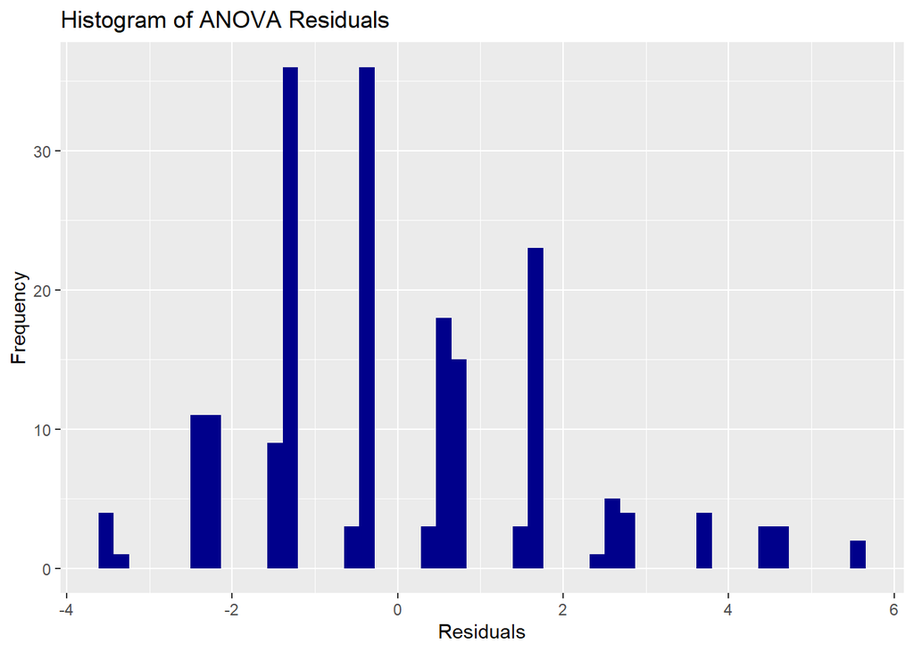

```r
df<-data.frame(anova.residuals)

ggplot(df, aes(x = anova.residuals)) +
  geom_histogram(bins=50,fill="blue4") +
  labs(title = "Histogram of ANOVA Residuals", x = "Residuals", y = "Frequency")
```

3.Independence test

- HO : observations are independent in the population.
- H1 : observations are not independent in the population

```r
dw.data=durbinWatsonTest(anov)
dw.data
```

```
##  lag Autocorrelation D-W Statistic p-value
##    1     -0.03953443      2.067412   0.668
##  Alternative hypothesis: rho != 0
```

Kruskal Wallis Test

- H0: The population medians of daily listening time grouped according to degree program is equal to each other.
- H1: At least one of the population medians of the daily listening time is not equal to another.

```r
kr.data=kruskal.test(Daily_listening_time ~ Degree_program,data = df_cleaned)
kr.data
```

```
##
##  Kruskal-Wallis rank sum test
##
## data:  Daily_listening_time by Degree_program
## Kruskal-Wallis chi-squared = 13.192, df = 4, p-value = 0.01037
```